# hw6

Section 6.6 Exercises 1, 4, 8, 10

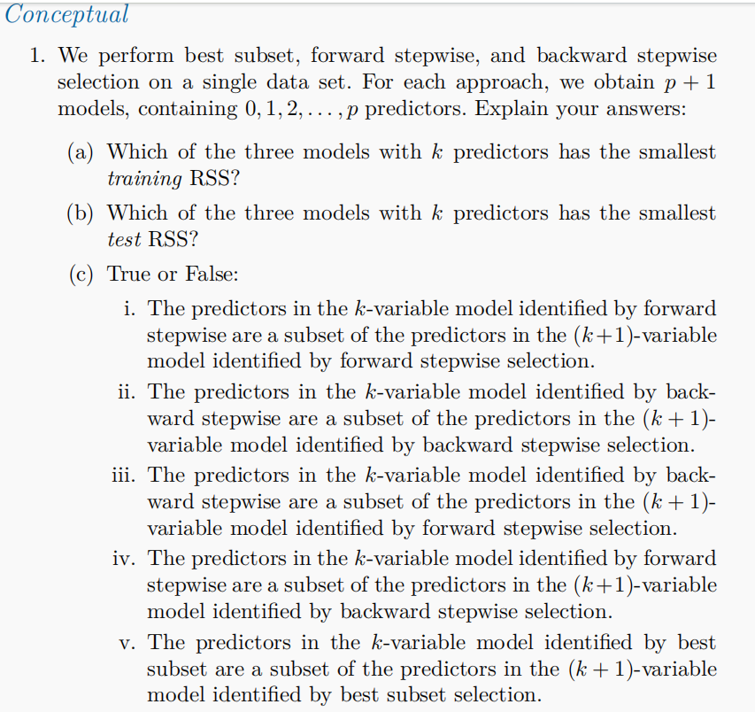

a

最佳子集考虑了大多数模型（考虑了$p$预测变量的所有可能组合），因此这将给出最小的训练RSS（它将至少考虑前向和后向逐步选择所涵盖的所有可能性）。然而，这三种方法在实践中即使不完全相同，也有望给出相似的结果。

b

无法判断哪种模型在测试RSS上表现最好。答案将取决于对数据的拟合和过拟合之间的权衡。

c

i：T。随着$k$的增加，前向逐步选择保留了以前模型中识别的所有特征。

ii：T。随着$k$的减少，向后逐步选择删除一个一个的特征。

iii：F。由于算法的不同，前向和后向逐步选择可以识别不同的变量组合。

iv：F。由于算法的不同，前向和后向逐步选择可以识别不同的变量组合。

v：F。最佳子集选择可以通过考虑所有可能的模型来识别每个$k$变量的不同组合。

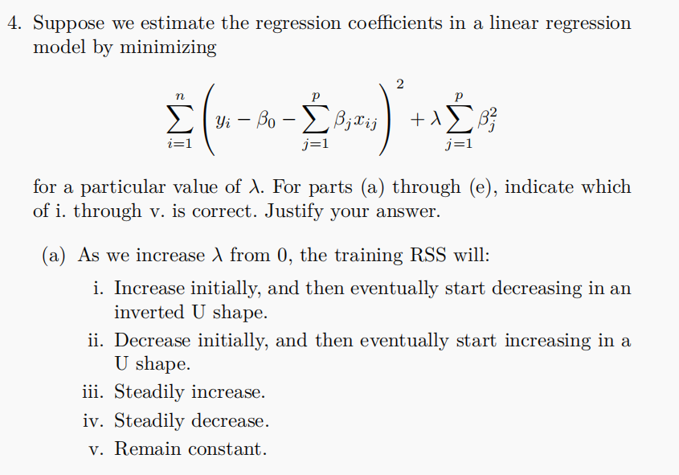

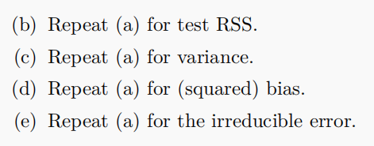

a

随着$\lambda$的增加，平方和的权重增加，因此模型变得不那么灵活。因此，训练集RSS必然增加，iii

b

当$\lambda$增加时，灵活性降低，因此测试集上RSS将减少（方差减少），但随后会增加（偏差增加），ii

c

稳步下降，iv

不可约误差不变，v

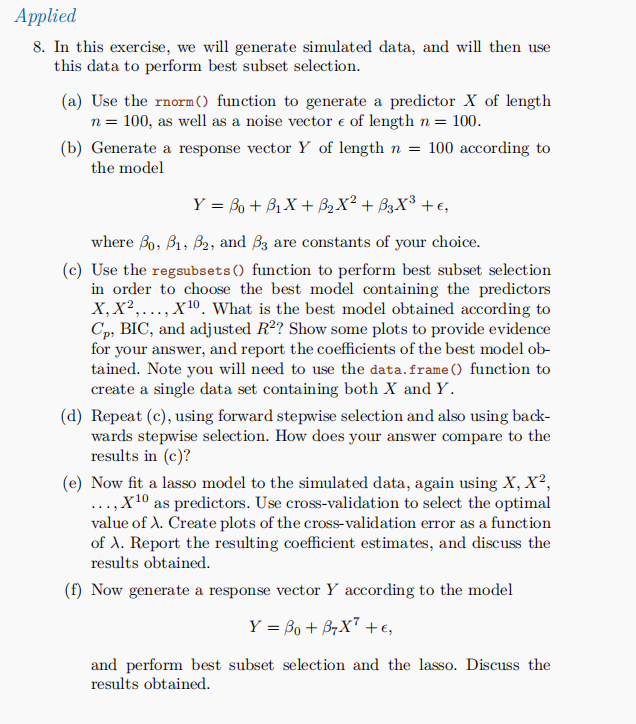

```r
# a
library(ISLR2)
library(glmnet)
library(leaps)
library(pls)

set.seed(2025)
x <- rnorm(100)
ep <- rnorm(100)
```

```r
# b
y <- 2 + 3 * x - 2 * x^2 + 0.5 * x^3 + ep
```

```r
# c

dat <- data.frame(x, y)
summary(regsubsets(y ~ poly(x, 10, raw = TRUE), data = dat))
```

```
Subset selection object
Call: regsubsets.formula(y ~ poly(x, 10, raw = TRUE), data = dat)
10 Variables  (and intercept)
                          Forced in Forced out
poly(x, 10, raw = TRUE)1      FALSE      FALSE
poly(x, 10, raw = TRUE)2      FALSE      FALSE
poly(x, 10, raw = TRUE)3      FALSE      FALSE
poly(x, 10, raw = TRUE)4      FALSE      FALSE
poly(x, 10, raw = TRUE)5      FALSE      FALSE
poly(x, 10, raw = TRUE)6      FALSE      FALSE
poly(x, 10, raw = TRUE)7      FALSE      FALSE
poly(x, 10, raw = TRUE)8      FALSE      FALSE
poly(x, 10, raw = TRUE)9      FALSE      FALSE
poly(x, 10, raw = TRUE)10     FALSE      FALSE
1 subsets of each size up to 8
Selection Algorithm: exhaustive
         poly(x, 10, raw = TRUE)1 poly(x, 10, raw = TRUE)2
1  ( 1 ) "*"                      " "
2  ( 1 ) "*"                      "*"
3  ( 1 ) "*"                      "*"
4  ( 1 ) "*"                      "*"
5  ( 1 ) "*"                      "*"
6  ( 1 ) "*"                      "*"
7  ( 1 ) "*"                      "*"
8  ( 1 ) "*"                      "*"
         poly(x, 10, raw = TRUE)3 poly(x, 10, raw = TRUE)4
1  ( 1 ) " "                      " "
2  ( 1 ) " "                      " "
3  ( 1 ) "*"                      " "
4  ( 1 ) "*"                      "*"
5  ( 1 ) "*"                      " "
6  ( 1 ) "*"                      " "
7  ( 1 ) "*"                      " "
8  ( 1 ) " "                      " "
         poly(x, 10, raw = TRUE)5 poly(x, 10, raw = TRUE)6
1  ( 1 ) " "                      " "
2  ( 1 ) " "                      " "
3  ( 1 ) " "                      " "
4  ( 1 ) " "                      " "
5  ( 1 ) " "                      " "
6  ( 1 ) "*"                      " "
7  ( 1 ) " "                      " "
8  ( 1 ) "*"                      "*"
         poly(x, 10, raw = TRUE)7 poly(x, 10, raw = TRUE)8
1  ( 1 ) " "                      " "
2  ( 1 ) " "                      " "
3  ( 1 ) " "                      " "
4  ( 1 ) " "                      " "
5  ( 1 ) " "                      " "
6  ( 1 ) "*"                      " "
7  ( 1 ) "*"                      "*"
8  ( 1 ) "*"                      "*"
         poly(x, 10, raw = TRUE)9 poly(x, 10, raw = TRUE)10
1  ( 1 ) " "                      " "
2  ( 1 ) " "                      " "
3  ( 1 ) " "                      " "
4  ( 1 ) " "                      " "
5  ( 1 ) "*"                      "*"
6  ( 1 ) " "                      "*"
7  ( 1 ) "*"                      "*"
8  ( 1 ) "*"                      "*"
```

```r
# d

summary(regsubsets(y ~ poly(x, 10, raw = TRUE), data = dat, method = "forward"))
summary(regsubsets(y ~ poly(x, 10, raw = TRUE), data = dat, method = "backward"))
```

```
Subset selection object
Call: regsubsets.formula(y ~ poly(x, 10, raw = TRUE), data = dat, method = "forward")
10 Variables  (and intercept)
                          Forced in Forced out
poly(x, 10, raw = TRUE)1      FALSE      FALSE
poly(x, 10, raw = TRUE)2      FALSE      FALSE
poly(x, 10, raw = TRUE)3      FALSE      FALSE
poly(x, 10, raw = TRUE)4      FALSE      FALSE
poly(x, 10, raw = TRUE)5      FALSE      FALSE
poly(x, 10, raw = TRUE)6      FALSE      FALSE
poly(x, 10, raw = TRUE)7      FALSE      FALSE
poly(x, 10, raw = TRUE)8      FALSE      FALSE
poly(x, 10, raw = TRUE)9      FALSE      FALSE
poly(x, 10, raw = TRUE)10     FALSE      FALSE
1 subsets of each size up to 8
Selection Algorithm: forward
         poly(x, 10, raw = TRUE)1 poly(x, 10, raw = TRUE)2
1  ( 1 ) "*"                      " "
2  ( 1 ) "*"                      "*"
3  ( 1 ) "*"                      "*"
4  ( 1 ) "*"                      "*"
5  ( 1 ) "*"                      "*"
6  ( 1 ) "*"                      "*"
7  ( 1 ) "*"                      "*"
8  ( 1 ) "*"                      "*"
         poly(x, 10, raw = TRUE)3 poly(x, 10, raw = TRUE)4
1  ( 1 ) " "                      " "
2  ( 1 ) " "                      " "
3  ( 1 ) "*"                      " "
4  ( 1 ) "*"                      "*"
5  ( 1 ) "*"                      "*"
6  ( 1 ) "*"                      "*"
7  ( 1 ) "*"                      "*"
8  ( 1 ) "*"                      "*"
         poly(x, 10, raw = TRUE)5 poly(x, 10, raw = TRUE)6
1  ( 1 ) " "                      " "
2  ( 1 ) " "                      " "
3  ( 1 ) " "                      " "
4  ( 1 ) " "                      " "
5  ( 1 ) " "                      " "
6  ( 1 ) " "                      " "
7  ( 1 ) " "                      " "
8  ( 1 ) " "                      " "
         poly(x, 10, raw = TRUE)7 poly(x, 10, raw = TRUE)8
1  ( 1 ) " "                      " "
2  ( 1 ) " "                      " "
3  ( 1 ) " "                      " "
4  ( 1 ) " "                      " "
5  ( 1 ) "*"                      " "
6  ( 1 ) "*"                      " "
7  ( 1 ) "*"                      " "
8  ( 1 ) "*"                      "*"
         poly(x, 10, raw = TRUE)9 poly(x, 10, raw = TRUE)10
1  ( 1 ) " "                      " "
2  ( 1 ) " "                      " "
3  ( 1 ) " "                      " "
4  ( 1 ) " "                      " "
5  ( 1 ) " "                      " "
6  ( 1 ) " "                      "*"
7  ( 1 ) "*"                      "*"
8  ( 1 ) "*"                      "*"
```

```
Subset selection object
Call: regsubsets.formula(y ~ poly(x, 10, raw = TRUE), data = dat, method = "backward")
10 Variables  (and intercept)
                          Forced in Forced out
poly(x, 10, raw = TRUE)1      FALSE      FALSE
poly(x, 10, raw = TRUE)2      FALSE      FALSE
poly(x, 10, raw = TRUE)3      FALSE      FALSE
poly(x, 10, raw = TRUE)4      FALSE      FALSE
poly(x, 10, raw = TRUE)5      FALSE      FALSE
poly(x, 10, raw = TRUE)6      FALSE      FALSE
poly(x, 10, raw = TRUE)7      FALSE      FALSE
poly(x, 10, raw = TRUE)8      FALSE      FALSE
poly(x, 10, raw = TRUE)9      FALSE      FALSE
poly(x, 10, raw = TRUE)10     FALSE      FALSE
1 subsets of each size up to 8
Selection Algorithm: backward
         poly(x, 10, raw = TRUE)1 poly(x, 10, raw = TRUE)2
1  ( 1 ) "*"                      " "
2  ( 1 ) "*"                      "*"
3  ( 1 ) "*"                      "*"
4  ( 1 ) "*"                      "*"
5  ( 1 ) "*"                      "*"
6  ( 1 ) "*"                      "*"
7  ( 1 ) "*"                      "*"
8  ( 1 ) "*"                      "*"
         poly(x, 10, raw = TRUE)3 poly(x, 10, raw = TRUE)4
1  ( 1 ) " "                      " "
2  ( 1 ) " "                      " "
3  ( 1 ) " "                      " "
4  ( 1 ) " "                      " "
5  ( 1 ) " "                      " "
6  ( 1 ) " "                      " "
7  ( 1 ) " "                      " "
8  ( 1 ) " "                      " "
         poly(x, 10, raw = TRUE)5 poly(x, 10, raw = TRUE)6
1  ( 1 ) " "                      " "
2  ( 1 ) " "                      " "
3  ( 1 ) "*"                      " "
4  ( 1 ) "*"                      " "
5  ( 1 ) "*"                      " "
6  ( 1 ) "*"                      " "
7  ( 1 ) "*"                      " "
8  ( 1 ) "*"                      "*"
         poly(x, 10, raw = TRUE)7 poly(x, 10, raw = TRUE)8
1  ( 1 ) " "                      " "
2  ( 1 ) " "                      " "
3  ( 1 ) " "                      " "
4  ( 1 ) " "                      " "
5  ( 1 ) "*"                      " "
6  ( 1 ) "*"                      " "
7  ( 1 ) "*"                      "*"
8  ( 1 ) "*"                      "*"
         poly(x, 10, raw = TRUE)9 poly(x, 10, raw = TRUE)10
1  ( 1 ) " "                      " "
2  ( 1 ) " "                      " "
3  ( 1 ) " "                      " "
4  ( 1 ) " "                      "*"
5  ( 1 ) " "                      "*"
6  ( 1 ) "*"                      "*"
7  ( 1 ) "*"                      "*"
8  ( 1 ) "*"                      "*"
```

0.147043832315051

```
11 x 1 sparse Matrix of class "dgCMatrix"
                       s1
(Intercept)  1.9020318266
1            2.8400741333
2           -1.8926347246
3            0.4732666350
4           -0.0004636195
5            .
6            .
7            .
8            .
9            .
10           .
```

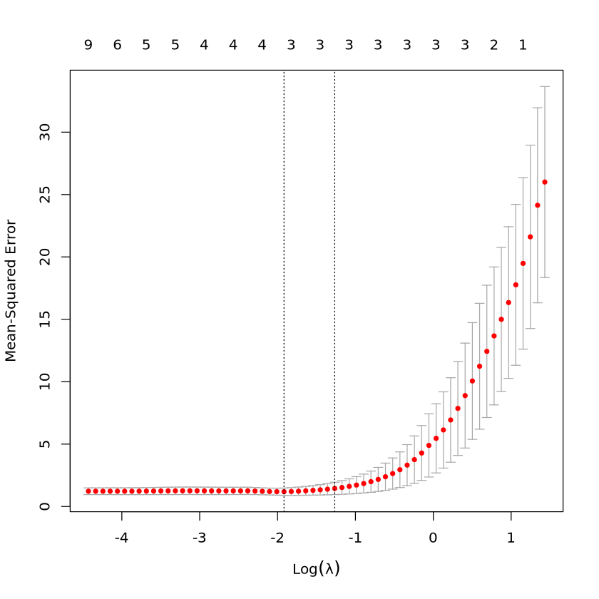

```r
# e

res <- cv.glmnet(poly(dat$x, 10, raw = TRUE), dat$y, alpha = 1)
(best <- res$lambda.min)
plot(res)
out <- glmnet(poly(dat$x, 10, raw = TRUE), dat$y, alpha = 1, lambda = res$lambda.min)
predict(out, type = "coefficients", s = best)
```

```
Subset selection object
Call: regsubsets.formula(y ~ poly(x, 10, raw = TRUE), data = dat)
10 Variables  (and intercept)
                          Forced in Forced out
poly(x, 10, raw = TRUE)1      FALSE      FALSE
poly(x, 10, raw = TRUE)2      FALSE      FALSE
poly(x, 10, raw = TRUE)3      FALSE      FALSE
poly(x, 10, raw = TRUE)4      FALSE      FALSE
poly(x, 10, raw = TRUE)5      FALSE      FALSE
poly(x, 10, raw = TRUE)6      FALSE      FALSE
poly(x, 10, raw = TRUE)7      FALSE      FALSE
poly(x, 10, raw = TRUE)8      FALSE      FALSE
poly(x, 10, raw = TRUE)9      FALSE      FALSE
poly(x, 10, raw = TRUE)10     FALSE      FALSE
1 subsets of each size up to 8
Selection Algorithm: exhaustive
         poly(x, 10, raw = TRUE)1 poly(x, 10, raw = TRUE)2
1  ( 1 ) " "                      " "
2  ( 1 ) " "                      "*"
3  ( 1 ) " "                      "*"
4  ( 1 ) " "                      "*"
5  ( 1 ) " "                      "*"
6  ( 1 ) " "                      "*"
7  ( 1 ) " "                      "*"
8  ( 1 ) " "                      "*"
         poly(x, 10, raw = TRUE)3 poly(x, 10, raw = TRUE)4
1  ( 1 ) " "                      " "
2  ( 1 ) " "                      " "
3  ( 1 ) " "                      "*"
4  ( 1 ) " "                      " "
5  ( 1 ) " "                      " "
6  ( 1 ) " "                      "*"
7  ( 1 ) "*"                      " "
8  ( 1 ) "*"                      " "
         poly(x, 10, raw = TRUE)5 poly(x, 10, raw = TRUE)6
1  ( 1 ) " "                      " "
2  ( 1 ) " "                      " "
3  ( 1 ) " "                      " "
4  ( 1 ) "*"                      " "
5  ( 1 ) " "                      " "
6  ( 1 ) " "                      "*"
7  ( 1 ) "*"                      "*"
8  ( 1 ) "*"                      "*"
         poly(x, 10, raw = TRUE)7 poly(x, 10, raw = TRUE)8
1  ( 1 ) "*"                      " "
2  ( 1 ) "*"                      " "
3  ( 1 ) "*"                      " "
4  ( 1 ) "*"                      " "
5  ( 1 ) "*"                      "*"
6  ( 1 ) "*"                      " "
7  ( 1 ) " "                      "*"
8  ( 1 ) "*"                      "*"
         poly(x, 10, raw = TRUE)9 poly(x, 10, raw = TRUE)10
1  ( 1 ) " "                      " "
2  ( 1 ) " "                      " "
3  ( 1 ) " "                      " "
4  ( 1 ) " "                      "*"
5  ( 1 ) "*"                      "*"
6  ( 1 ) "*"                      "*"
7  ( 1 ) "*"                      "*"
8  ( 1 ) "*"                      "*"
```

0.24349797952428

```
11 x 1 sparse Matrix of class "dgCMatrix"
                     s1
(Intercept)  1.74114494
1            .
2           -1.70295692
3            .
4            .
5            0.02987375
6            .
7            0.19353748
8            .
9            .
10           .
```

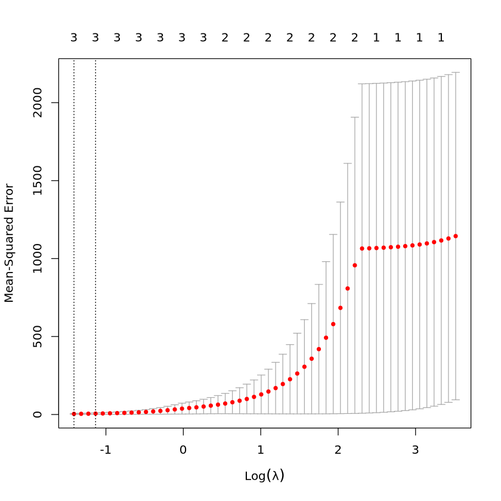

```r
# f

dat$y <- 2 - 2 * x^2 + 0.2 * x^7 + ep
summary(regsubsets(y ~ poly(x, 10, raw = TRUE), data = dat))

res <- cv.glmnet(poly(dat$x, 10, raw = TRUE), dat$y, alpha = 1)
(best <- res$lambda.min)
plot(res)
out <- glmnet(poly(dat$x, 10, raw = TRUE), dat$y, alpha = 1, lambda = best)
predict(out, type = "coefficients", s = best)
```

当拟合lasso时，模型不能完美地匹配模拟（系数保留为未模拟的$x$的幂）。

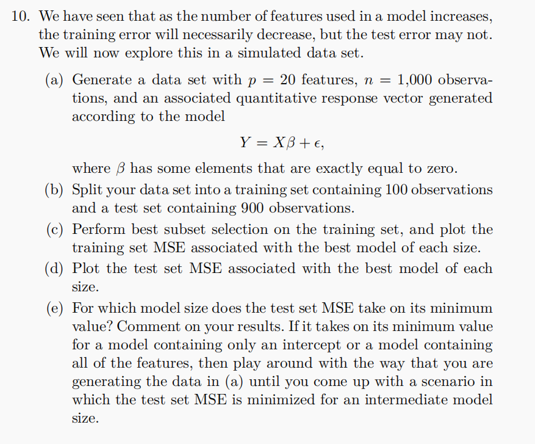

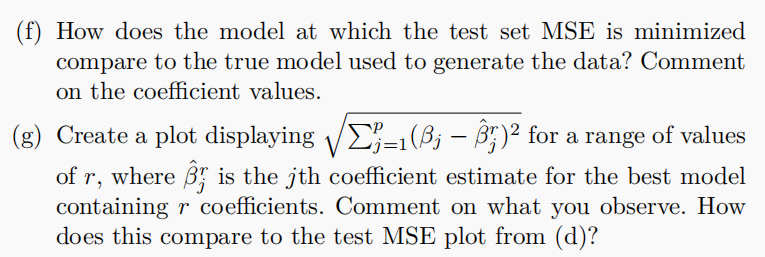

```r
# a


set.seed(2025)
dat <- matrix(rnorm(1000 * 20), nrow = 1000)
colnames(dat) <- paste0("b", 1:20)
beta <- rep(0, 20)
beta[1:4] <- c(5, 4, 2, 7)
y <- colSums((t(dat) * beta)) + rnorm(1000)
dat <- data.frame(dat)
dat$y <- y
```

```r
# b
train <- dat[1:100, ]
test <- dat[101:1000, ]
```

```
Subset selection object
Call: regsubsets.formula(y ~ ., data = train, nvmax = 20)
20 Variables  (and intercept)
    Forced in Forced out
b1      FALSE      FALSE
b2      FALSE      FALSE
b3      FALSE      FALSE
b4      FALSE      FALSE
b5      FALSE      FALSE
b6      FALSE      FALSE
b7      FALSE      FALSE
b8      FALSE      FALSE
b9      FALSE      FALSE
b10     FALSE      FALSE
b11     FALSE      FALSE
b12     FALSE      FALSE
b13     FALSE      FALSE
b14     FALSE      FALSE
b15     FALSE      FALSE
b16     FALSE      FALSE
b17     FALSE      FALSE
b18     FALSE      FALSE
b19     FALSE      FALSE
b20     FALSE      FALSE
1 subsets of each size up to 20
Selection Algorithm: exhaustive
          b1  b2  b3  b4  b5  b6  b7  b8  b9  b10 b11 b12 b13 b14 b15 b16 b17
1  ( 1 )  " " " " " " "*" " " " " " " " " " " " " " " " " " " " " " " " " " "
2  ( 1 )  "*" " " " " "*" " " " " " " " " " " " " " " " " " " " " " " " " " "
3  ( 1 )  "*" "*" " " "*" " " " " " " " " " " " " " " " " " " " " " " " " " "
4  ( 1 )  "*" "*" "*" "*" " " " " " " " " " " " " " " " " " " " " " " " " " "
5  ( 1 )  "*" "*" "*" "*" " " " " "*" " " " " " " " " " " " " " " " " " " " "
6  ( 1 )  "*" "*" "*" "*" " " " " "*" " " " " " " " " " " " " "*" " " " " " "
7  ( 1 )  "*" "*" "*" "*" " " "*" "*" " " " " " " " " " " " " "*" " " " " " "
8  ( 1 )  "*" "*" "*" "*" " " "*" "*" " " " " " " " " " " " " "*" "*" " " " "
9  ( 1 )  "*" "*" "*" "*" " " "*" "*" " " " " " " " " " " " " "*" "*" " " "*"
10  ( 1 ) "*" "*" "*" "*" " " "*" "*" " " " " " " " " " " " " "*" "*" " " "*"
11  ( 1 ) "*" "*" "*" "*" " " "*" "*" " " " " " " " " " " " " "*" "*" "*" "*"
12  ( 1 ) "*" "*" "*" "*" " " "*" "*" " " " " " " " " " " " " "*" "*" "*" "*"
13  ( 1 ) "*" "*" "*" "*" " " "*" "*" " " "*" " " " " " " " " "*" "*" "*" "*"
```

[output cut: 13 more lines]

```
6  ( 1 )  " " " " " "
7  ( 1 )  " " " " " "
8  ( 1 )  " " " " " "
9  ( 1 )  " " " " " "
10  ( 1 ) " " " " "*"
11  ( 1 ) " " " " "*"
12  ( 1 ) "*" " " "*"
13  ( 1 ) "*" " " "*"
14  ( 1 ) "*" "*" "*"
15  ( 1 ) "*" "*" "*"
16  ( 1 ) "*" "*" "*"
17  ( 1 ) "*" "*" "*"
18  ( 1 ) "*" "*" "*"
19  ( 1 ) "*" "*" "*"
20  ( 1 ) "*" "*" "*"
```

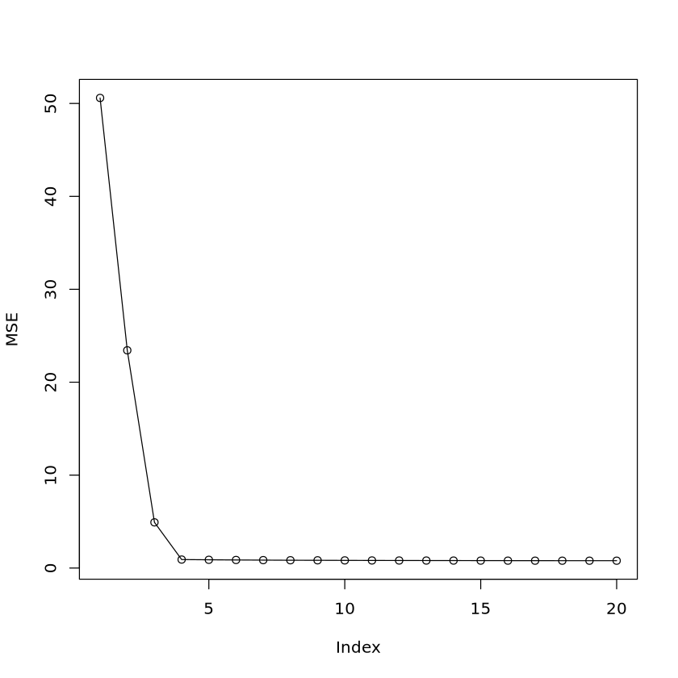

```r
# c
fit <- regsubsets(y ~ ., data = train, nvmax = 20)
summary(fit)
plot(summary(fit)$rss / 100, ylab = "MSE", type = "o")
```

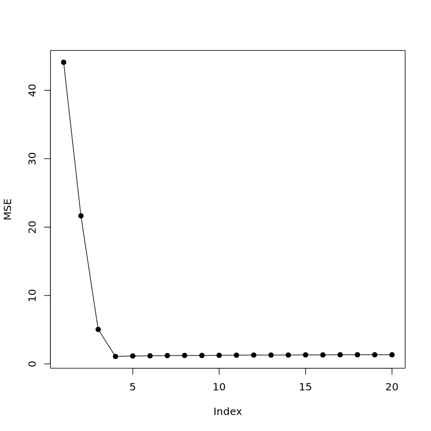

```r
# d
predict.regsubsets <- function(object, newdata, id, ...) {
  form <- as.formula(object$call[[2]])
  mat <- model.matrix(form, newdata)
  coefi <- coef(object, id = id)
  xvars <- names(coefi)
  mat[, xvars] %*% coefi
}
mse <- sapply(1:20, function(i) mean((test$y - predict(fit, test, i))^2))
plot(mse, ylab = "MSE", type = "o", pch = 19)
```

```r
# e
which.min(mse)

# 当模型大小为4时，发现最小检验MSE。这与有四个非零系数的模拟数据相对应。
```

4

```
Subset selection object
Call: regsubsets.formula(y ~ ., data = train, nvmax = 20)
20 Variables  (and intercept)
    Forced in Forced out
b1      FALSE      FALSE
b2      FALSE      FALSE
b3      FALSE      FALSE
b4      FALSE      FALSE
b5      FALSE      FALSE
b6      FALSE      FALSE
b7      FALSE      FALSE
b8      FALSE      FALSE
b9      FALSE      FALSE
b10     FALSE      FALSE
b11     FALSE      FALSE
b12     FALSE      FALSE
b13     FALSE      FALSE
b14     FALSE      FALSE
b15     FALSE      FALSE
b16     FALSE      FALSE
b17     FALSE      FALSE
b18     FALSE      FALSE
b19     FALSE      FALSE
b20     FALSE      FALSE
1 subsets of each size up to 20
Selection Algorithm: exhaustive
          b1  b2  b3  b4  b5  b6  b7  b8  b9  b10 b11 b12 b13 b14 b15 b16 b17
1  ( 1 )  " " " " " " "*" " " " " " " " " " " " " " " " " " " " " " " " " " "
2  ( 1 )  "*" " " " " "*" " " " " " " " " " " " " " " " " " " " " " " " " " "
3  ( 1 )  "*" "*" " " "*" " " " " " " " " " " " " " " " " " " " " " " " " " "
4  ( 1 )  "*" "*" "*" "*" " " " " " " " " " " " " " " " " " " " " " " " " " "
5  ( 1 )  "*" "*" "*" "*" " " " " " " " " "*" " " " " " " " " " " " " " " " "
6  ( 1 )  "*" "*" "*" "*" " " " " "*" " " "*" " " " " " " " " " " " " " " " "
7  ( 1 )  "*" "*" "*" "*" " " " " "*" " " "*" " " " " " " " " "*" " " " " " "
8  ( 1 )  "*" "*" "*" "*" " " "*" "*" " " "*" " " " " " " " " "*" " " " " " "
9  ( 1 )  "*" "*" "*" "*" " " "*" "*" " " "*" " " " " " " " " "*" "*" " " " "
10  ( 1 ) "*" "*" "*" "*" " " "*" "*" " " "*" " " " " " " " " "*" "*" " " " "
11  ( 1 ) "*" "*" "*" "*" " " "*" "*" " " "*" " " " " " " " " "*" "*" " " "*"
12  ( 1 ) "*" "*" "*" "*" " " "*" "*" " " "*" " " " " " " " " "*" "*" "*" "*"
13  ( 1 ) "*" "*" "*" "*" "*" "*" "*" " " "*" " " " " " " " " "*" "*" "*" "*"
```

[output cut: 13 more lines]

```
6  ( 1 )  " " " " " "
7  ( 1 )  " " " " " "
8  ( 1 )  " " " " " "
9  ( 1 )  " " " " " "
10  ( 1 ) " " " " "*"
11  ( 1 ) " " " " "*"
12  ( 1 ) " " " " "*"
13  ( 1 ) " " " " "*"
14  ( 1 ) " " "*" "*"
15  ( 1 ) " " "*" "*"
16  ( 1 ) "*" "*" "*"
17  ( 1 ) "*" "*" "*"
18  ( 1 ) "*" "*" "*"
19  ( 1 ) "*" "*" "*"
20  ( 1 ) "*" "*" "*"
```

5

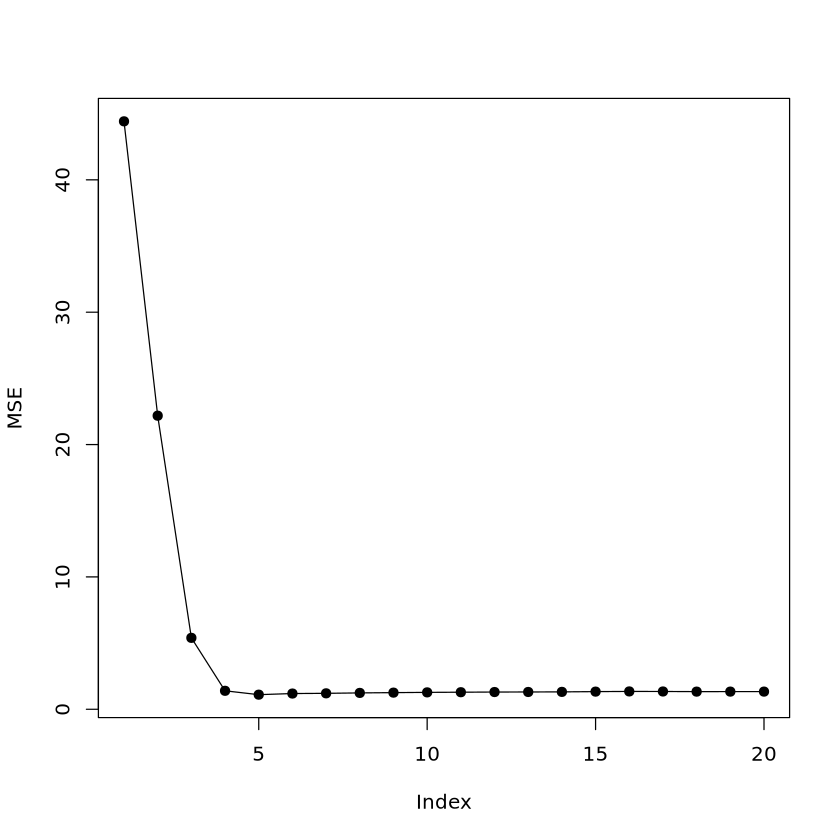

```r
set.seed(2025)
dat <- matrix(rnorm(1000 * 20), nrow = 1000)
colnames(dat) <- paste0("b", 1:20)
beta <- rep(0, 20)
beta[1:9] <- c(5, 4, 2, 7, 0.01, 0.001, 0.05, 0.1, 0.5)
y <- colSums((t(dat) * beta)) + rnorm(1000)
dat <- data.frame(dat)
dat$y <- y
train <- dat[1:100, ]
test <- dat[101:1000, ]

fit <- regsubsets(y ~ ., data = train, nvmax = 20)
summary(fit)
mse <- sapply(1:20, function(i) mean((test$y - predict(fit, test, i))^2))
plot(mse, ylab = "MSE", type = "o", pch = 19)
which.min(mse)
```

当模型大小为5，但有9个非零系数时，有最小的测试集MSE。

```r
# f
coef(fit, id = 5)

# 当系数值较高时，可以很好地估计，但较小的系数会被丢弃。
```

**(Intercept)**

0.143715863306038

**b1**

4.95616537320666

**b2**

3.85191421256802

**b3**

2.00200853344046

**b4**

6.95685286210765

**b9**

0.603342794150117

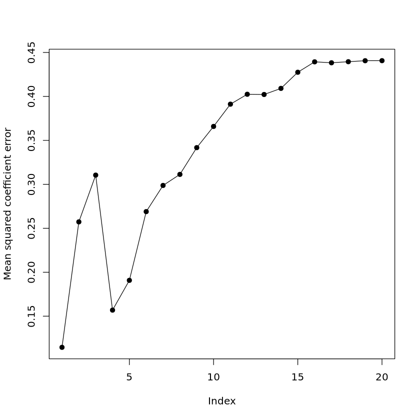

```r
# g

names(beta) <- paste0("b", 1:20)
b <- data.frame(id = names(beta), b = beta)

out <- sapply(1:20, function(i) {
  c <- coef(fit, id = i)[-1]
  c <- data.frame(id = names(c), c = c)
  m <- merge(b, c)
  sqrt(sum((m$b - m$c)^2))
})
plot(out, ylab = "Mean squared coefficient error", type = "o", pch = 19)
```